# Wrangling rasters: from satellite image to dataframe format in R

## Calculate new values based on your dataframe. Example: Normalised Differenced Vegetation Index (NDVI)

```r
ndvCalc <- function(x) {
  ndvi <- (x[[4]] - x[[3]]) / (x[[4]] + x[[3]])
  return(ndvi)
}
```

Calculate NDVI for the entire Injune landsat scene, which is in our Rasterstack img.

```r
ndvi <- calc(x=img, fun=ndvCalc)
```

Plot ndvi.

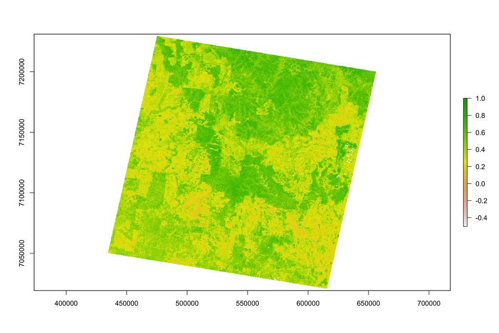

```r
plot(ndvi)
```

I want to extract data from the landsat imagery in raster format into data frame format suitable to run analyses on. Store NDVI in a dataframe format.

```r
ndvi.df = as.data.frame(ndvi, na.rm = TRUE)

str(ndvi.df) #'ndvi.df created a dataframe
```

```
## 'data.frame':    37405754 obs. of  1 variable:
##  $ layer: num  0.604 0.588 0.598 0.605 0.604 ...
```

```r
head(ndvi.df)
```

```
##            layer
## 373427 0.6040269
## 373428 0.5884956
## 373429 0.5984766
## 381337 0.6045752
## 381338 0.6036036
## 381339 0.5886674
```

Label ‘layer’ column as NDVI

```r
colnames(ndvi.df) <- "NDVI"
```

Add NDVI to the data dataframe and call it allvars (all variables).

```r
allvars <- cbind(data, ndvi.df[,1, drop=FALSE])
```

I don’t want to include any NDVI values less than 0, as these indicate the pixel is water and out of scope of this example.

Store all the observations with NDVI value greater than 0 in a dataframe called ‘data.final’.

```r
data.final <-subset(allvars, NDVI > 0)
summary(data.final) #' Confirms minimum value of NDVI is zero
```

```
##      Band1            Band2            Band3            Band4
##  Min.   :   0.0   Min.   :   0.0   Min.   :   0.0   Min.   : 132
##  1st Qu.: 210.0   1st Qu.: 351.0   1st Qu.: 450.0   1st Qu.:1491
##  Median : 318.0   Median : 506.0   Median : 696.0   Median :1638
##  Mean   : 327.6   Mean   : 517.5   Mean   : 704.3   Mean   :1657
##  3rd Qu.: 437.0   3rd Qu.: 666.0   3rd Qu.: 933.0   3rd Qu.:1799
##  Max.   :5174.0   Max.   :5387.0   Max.   :5721.0   Max.   :6541
##      Band5          Band6        Longitude        Latitude
##  Min.   :   0   Min.   :   0   Min.   :146.3   Min.   :-26.93
##  1st Qu.:1623   1st Qu.: 973   1st Qu.:147.0   1st Qu.:-26.40
##  Median :2219   Median :1483   Median :147.5   Median :-25.99
##  Mean   :2224   Mean   :1495   Mean   :147.5   Mean   :-25.99
##  3rd Qu.:2784   3rd Qu.:1971   3rd Qu.:147.9   3rd Qu.:-25.59
##  Max.   :8233   Max.   :8756   Max.   :148.6   Max.   :-25.05
##       NDVI
##  Min.   :0.0006325
##  1st Qu.:0.2904725
##  Median :0.4159021
##  Mean   :0.4247050
##  3rd Qu.:0.5491667
##  Max.   :1.0000000
```

Manually calculated NDVI and values are correct. Create a variable called class based on the ndvi.df dataframe, which gives land cover category based on NDVI cut off values. I am using 0.4 as an example, but you could set other thresholds based on remote sensing rules or your own preferences.

```r
class <-c(ifelse(data.final$NDVI >0.4,"Forest","Pasture"))
head(class)
```

```
## [1] "Forest" "Forest" "Forest" "Forest" "Forest" "Forest"
```

Create a dataframe called final.data including data.final and using cbind to add class.

```r
final.data <-cbind(data.final, class)
colnames(final.data[10]) <- "Class"
head(final.data)
```

```
##        Band1 Band2 Band3 Band4 Band5 Band6 Longitude  Latitude      NDVI
## 373427   234   307   354  1434  1031   612  146.7538 -25.04913 0.6040269
## 373428    98   265   372  1436  1145   678  146.7541 -25.04913 0.5884956
## 373429   199   298   369  1469  1220   670  146.7544 -25.04913 0.5984766
## 381337    70   315   363  1473  1309   813  146.7535 -25.04940 0.6045752
## 381338   245   358   374  1513  1257   745  146.7538 -25.04940 0.6036036
## 381339   172   278   392  1514  1343   632  146.7541 -25.04940 0.5886674
##         class
## 373427 Forest
## 373428 Forest
## 373429 Forest
## 381337 Forest
## 381338 Forest
## 381339 Forest
```

```r
summary(final.data)
```

```
##      Band1            Band2            Band3            Band4
##  Min.   :   0.0   Min.   :   0.0   Min.   :   0.0   Min.   : 132
##  1st Qu.: 210.0   1st Qu.: 351.0   1st Qu.: 450.0   1st Qu.:1491
##  Median : 318.0   Median : 506.0   Median : 696.0   Median :1638
##  Mean   : 327.6   Mean   : 517.5   Mean   : 704.3   Mean   :1657
##  3rd Qu.: 437.0   3rd Qu.: 666.0   3rd Qu.: 933.0   3rd Qu.:1799
##  Max.   :5174.0   Max.   :5387.0   Max.   :5721.0   Max.   :6541
##      Band5          Band6        Longitude        Latitude
##  Min.   :   0   Min.   :   0   Min.   :146.3   Min.   :-26.93
##  1st Qu.:1623   1st Qu.: 973   1st Qu.:147.0   1st Qu.:-26.40
##  Median :2219   Median :1483   Median :147.5   Median :-25.99
##  Mean   :2224   Mean   :1495   Mean   :147.5   Mean   :-25.99
##  3rd Qu.:2784   3rd Qu.:1971   3rd Qu.:147.9   3rd Qu.:-25.59
##  Max.   :8233   Max.   :8756   Max.   :148.6   Max.   :-25.05
##       NDVI               class
##  Min.   :0.0006325   Forest :19768928
##  1st Qu.:0.2904725   Pasture:17634154
##  Median :0.4159021
##  Mean   :0.4247050
##  3rd Qu.:0.5491667
##  Max.   :1.0000000
```

Initial data wrangling is complete at this point, so you can move on to analyses using final.data. You can apply these steps to other images and the principles apply to other image files e.g. tifs, not just .img. You can then treat your data as you would any other standard dataframe, e.g. subsample your data, fit models, produce summary statistics, etc.